# Visualisation Using Python: matplotlib

# Contents:

1. **matplotlib** Package
2. Figures vs Axes
3. Two API modes
4. **MATLAB-like API** $\leftarrow$

```python
import pandas as pd
import numpy as np
```

# 01. matplotlib Package

- comprehensive library for creating static, animated, and interactive visualizations in Python
- multi-platform data visualisation library **built on NumPy arrays**
- forms basis of many other popular Python plotting packages

Further Reading:

- https://matplotlib.org/index.html

### how to import? alias?

```python
import matplotlib.pyplot as plt
```

Further Reading:

- https://matplotlib.org/stable/api/_as_gen/matplotlib.pyplot.html?highlight=pyplot#module-matplotlib.pyplot

# 02. Anatomy of a Figure: Figures vs Axes

Figure = the whole figure

- axes
  - 2D vs 3D
- canvas
  - where everything is drawn
- artists
  - anything drawn on the canvas
- axes
  - 2D vs 3D
    - data is plotted within Axes
  - labels of the x and y axes
  - tick spacing
  - legends
  - etc
- canvas
  - where everything is drawn
  - i.e. upon which plots shown, one or more plots
    - may contain several axes
  - effectively invisible by user
- artists
  - anything drawn on the canvas
    - titles,
    - figure legends,
    - colour of the background,
    - etc
    - even the Figure, Axes, and Axis objects

[EXTRA reading]

- https://matplotlib.org/faq/usage_faq.html#usage
- artists
  - https://matplotlib.org/api/artist_api.html
  - https://matplotlib.org/tutorials/intermediate/artists.html

# 03. API modes

- two approaches to plotting with Matplotlib
  - Object Oriented API (follows the Python object model)
  - MATLAB-like API (aka pyplot API)

Further Reading:

- https://matplotlib.org/api/index.html
- https://matplotlib.org/tutorials/introductory/lifecycle.html

# 04. MATLAB-like API

- NOT objects
  - this is within the implementation
    - EASIER TO USE
    - Flexibility - lacking
- functions
  - affect a figure
    - creates a figure
    - creates a plotting area in a figure
    - plots some lines in a plotting area
    - decorates the plot with labels
    - etc

Further Reading:

- https://matplotlib.org/api/_as_gen/matplotlib.pyplot.html#module-matplotlib.pyplot
- https://matplotlib.org/tutorials/introductory/pyplot.html
- https://matplotlib.org/gallery/index.html#pyplots-examples

### Demonstration: trigonometric functions

$\sin(x)$

```python
X = np.arange(0, 2*np.pi, 0.01)
Y1 = np.sin(X)      # trigonometric sine
Y2 = np.cos(X)      # cosine
```

```python
print(f'The value of pi in numpy is approx {np.pi:.5f}') # using formatted string literals
```

```
The value of pi in numpy is approx 3.14159
```

- Jupyter notebook has a requirement: for multiple plots in a SAME axes and figure, all matplotlib code must be in the SAME cell
- OO-API: (to compare)

  ```
  fig = plt.figure()
  ax1 = fig.add_subplot(1, 1, 1, title='plots many')
  ax1.plot(X,Y1)
  ax1.plot(X,Y2)
  ```

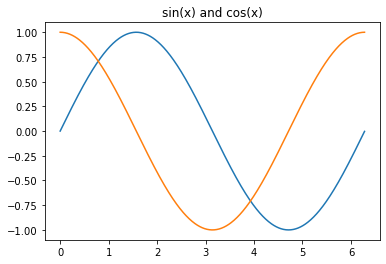

```python
plt.plot(X, Y1)                   # relies on "active" plt / figure / axes (implicitly)
plt.plot(X, Y2)                   # once plt created, it is NOT easy to go back and edit (is possible)
plt.title('sin(x) and cos(x)');   # behind the scenes - utilises OO api i.e. figure & axes
```

```python
plt.savefig('example_graphics_MATLAB-like-API.png')
```

### Changing Appearances: Axis Labels

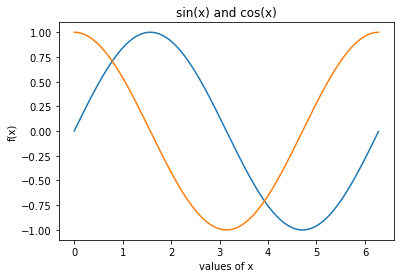

```python
plt.plot(X, Y1)
plt.plot(X, Y2)
plt.title('sin(x) and cos(x)')

plt.xlabel('values of x') # setting axis labels
plt.ylabel('f(x)');
```

### Changing Appearances: Adding Legends

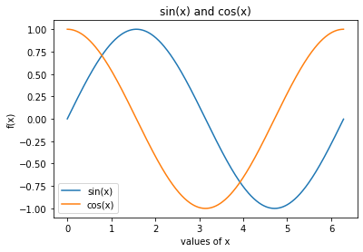

```python
plt.plot(X, Y1,   label = 'sin(x)'  )
plt.plot(X, Y2,   label = 'cos(x)'  )
plt.title('sin(x) and cos(x)')
plt.xlabel('values of x')
plt.ylabel('f(x)')

plt.legend(); # add a legend, (auto-generate using the axis labels)
```

[ASIDE] can specify legend:

- either, at artist creation (e.g. `plt.plot(X, Y, label='sin(x)')`)
- or, by calling the set_label() method

### Changing Appearances: Axis ticks

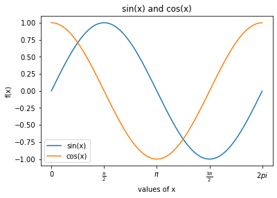

```python
plt.plot(X, Y1, label='sin(x)')
plt.plot(X, Y2, label='cos(x)')
plt.title('sin(x) and cos(x)'); plt.xlabel('values of x'); plt.ylabel('f(x)')
plt.legend()

plt.xticks( # setting up CUSTOM ticks in x-axis
            np.arange(0, 2*np.pi + 0.1, 0.5*np.pi),     # range of values: location of ticks
            ['0', '$\\frac{\pi}{2}$', '$\pi$', '$\\frac{3\pi}{2}$', '2$pi$']     # text labels (optional)
                   # notice the consequence of using "pi" instead of "\pi"
);
```

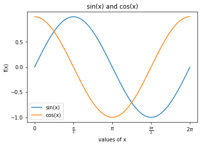

```python
plt.plot(X, Y1, label='sin(x)')
plt.plot(X, Y2, label='cos(x)')
plt.title('sin(x) and cos(x)'); plt.xlabel('values of x'); plt.ylabel('f(x)'); plt.legend()
plt.xticks(np.arange(0, 2*np.pi + 0.1, 0.5*np.pi),
           ['0', '$\\frac{\pi}{2}$', '$\pi$', '$\\frac{3\pi}{2}$', '2$\pi$'])

plt.yticks( # setting up custom ticks in y-axis
            # location of ticks
            np.arange(-1, 1, 0.5)   # notice that +1 is not visible, how can we fix this?
);
```

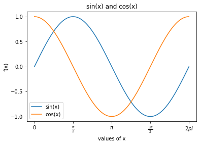

```python
plt.plot(X, Y1, label='sin(x)')
plt.plot(X, Y2, label='cos(x)')
plt.title('sin(x) and cos(x)'); plt.xlabel('values of x'); plt.ylabel('f(x)'); plt.legend()
plt.xticks(np.arange(0, 2*np.pi + 0.1, 0.5*np.pi),
           ['0', '$\\frac{\pi}{2}$', '$\pi$', '$\\frac{3\pi}{2}$', '2$pi$'])

plt.yticks( # setting up custom ticks in y-axis
            # location of ticks
            np.arange(-1, 1 + 0.1, 0.5)  # "+ 0.1" so we can see the whole plot
);
```

### Changing Appearances: Axis limits

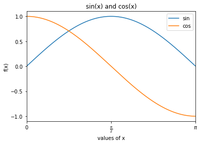

```python
plt.plot(X, Y1, label = "sin")
plt.plot(X, Y2, label = "cos")
plt.title('sin(x) and cos(x)'); plt.xlabel('values of x'); plt.ylabel('f(x)'); plt.legend()
plt.xticks(np.arange(0, 2*np.pi + 0.1, 0.5*np.pi),
           ['0', '$\\frac{\pi}{2}$', '$\pi$', '$\\frac{3\pi}{2}$', '2$pi$'])
plt.yticks(np.arange(-1, 1 + 0.1, 0.5))

plt.xlim( [0, np.pi] );  # setting x axis limits --> list object
```

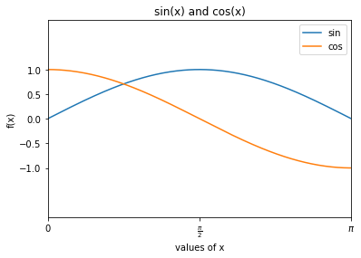

```python
plt.plot(X, Y1, label = "sin")
plt.plot(X, Y2, label = "cos")
plt.title('sin(x) and cos(x)'); plt.xlabel('values of x'); plt.ylabel('f(x)'); plt.legend()
plt.xticks(np.arange(0, 2*np.pi + 0.1, 0.5*np.pi),
           ['0', '$\\frac{\pi}{2}$', '$\pi$', '$\\frac{3\pi}{2}$', '2$pi$'])
plt.yticks(np.arange(-1, 1 + 0.1, 0.5))

plt.xlim( [0, np.pi] )

plt.ylim( [-2, 2] ); # setting y axis limits
```

### Demonstration: real dataset

```python
df_resp = pd.read_csv('data/responses.csv')

#  young persons survey (lifestyle/music perferences)
```

```python
type(df_resp)
```

```
pandas.core.frame.DataFrame
```

```python
df_resp.head(10)
```

|  | Music | Slow songs or fast songs | Dance | Folk | Country | Classical music | Musical | Pop | Rock | Metal or Hardrock | ... | Age | Height | Weight | Number of siblings | Gender | Left - right handed | Education | Only child | Village - town | House - block of flats |
| --- | --- | --- | --- | --- | --- | --- | --- | --- | --- | --- | --- | --- | --- | --- | --- | --- | --- | --- | --- | --- | --- |
| 0 | 5.0 | 3.0 | 2.0 | 1.0 | 2.0 | 2.0 | 1.0 | 5.0 | 5.0 | 1.0 | ... | 20.0 | 163.0 | 48.0 | 1.0 | female | right handed | college/bachelor degree | no | village | block of flats |
| 1 | 4.0 | 4.0 | 2.0 | 1.0 | 1.0 | 1.0 | 2.0 | 3.0 | 5.0 | 4.0 | ... | 19.0 | 163.0 | 58.0 | 2.0 | female | right handed | college/bachelor degree | no | city | block of flats |
| 2 | 5.0 | 5.0 | 2.0 | 2.0 | 3.0 | 4.0 | 5.0 | 3.0 | 5.0 | 3.0 | ... | 20.0 | 176.0 | 67.0 | 2.0 | female | right handed | secondary school | no | city | block of flats |
| 3 | 5.0 | 3.0 | 2.0 | 1.0 | 1.0 | 1.0 | 1.0 | 2.0 | 2.0 | 1.0 | ... | 22.0 | 172.0 | 59.0 | 1.0 | female | right handed | college/bachelor degree | yes | city | house/bungalow |
| 4 | 5.0 | 3.0 | 4.0 | 3.0 | 2.0 | 4.0 | 3.0 | 5.0 | 3.0 | 1.0 | ... | 20.0 | 170.0 | 59.0 | 1.0 | female | right handed | secondary school | no | village | house/bungalow |
| 5 | 5.0 | 3.0 | 2.0 | 3.0 | 2.0 | 3.0 | 3.0 | 2.0 | 5.0 | 5.0 | ... | 20.0 | 186.0 | 77.0 | 1.0 | male | right handed | secondary school | no | city | block of flats |
| 6 | 5.0 | 5.0 | 5.0 | 3.0 | 1.0 | 2.0 | 2.0 | 5.0 | 3.0 | 1.0 | ... | 20.0 | 177.0 | 50.0 | 1.0 | female | right handed | secondary school | no | village | house/bungalow |
| 7 | 5.0 | 3.0 | 3.0 | 2.0 | 1.0 | 2.0 | 2.0 | 4.0 | 5.0 | 1.0 | ... | 19.0 | 184.0 | 90.0 | 1.0 | male | right handed | college/bachelor degree | no | city | house/bungalow |
| 8 | 5.0 | 3.0 | 3.0 | 1.0 | 1.0 | 2.0 | 4.0 | 3.0 | 5.0 | 5.0 | ... | 18.0 | 166.0 | 55.0 | 1.0 | female | right handed | secondary school | no | city | house/bungalow |
| 9 | 5.0 | 3.0 | 2.0 | 5.0 | 2.0 | 2.0 | 5.0 | 3.0 | 5.0 | 2.0 | ... | 19.0 | 174.0 | 60.0 | 3.0 | female | right handed | secondary school | no | city | block of flats |

10 rows × 150 columns

#### Let us focus on two columns

```python
x = df_resp['Weight']
y = df_resp['Height']
```

```python
x
```

```
0       48.0
1       58.0
2       67.0
3       59.0
4       59.0
        ...
1005    57.0
1006    80.0
1007    75.0
1008    58.0
1009    72.0
Name: Weight, Length: 1010, dtype: float64
```

```python
y
```

```
0       163.0
1       163.0
2       176.0
3       172.0
4       170.0
        ...
1005    164.0
1006    183.0
1007    173.0
1008    173.0
1009    185.0
Name: Height, Length: 1010, dtype: float64
```

- OO-API: (to compare)

  ```
  fig = plt.figure()
  ax1 = fig.add_subplot(1, 1, 1)
  ax.scatter(x, y)
  ```

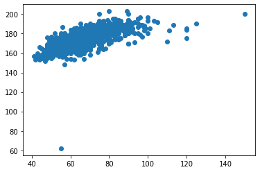

```python
plt.plot(x, y, 'o') # MATLAB-like API is much EASIER than the above OO-API, but less flexibilty
```

- number of participants for each gender

```python
df_resp['Gender'].value_counts()
```

```
female    593
male      411
Name: Gender, dtype: int64
```

- .plot() the above number of participants **using pandas**

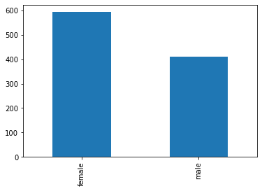

```python
df_resp['Gender'].value_counts().plot(kind = "bar"); # by default, pandas uses matplotlib
# https://pandas.pydata.org/pandas-docs/stable/reference/api/pandas.DataFrame.plot.html
```

Further Reading:

- https://matplotlib.org/api/_as_gen/matplotlib.pyplot.show.html